# Qn6 - 9

Tilak Poudel

2025-04-09

# Q.6

## a. Define integers from 1 to 15 using three diffrent coding approaches in R

### 1. Using the colon operator

```r
R <- 1:15
R
```

```
##  [1]  1  2  3  4  5  6  7  8  9 10 11 12 13 14 15
```

### 2. Using the seq() function

```r
R <- seq(1, 15)
R
```

```
##  [1]  1  2  3  4  5  6  7  8  9 10 11 12 13 14 15
```

### 3. Using the c() function

```r
R <- c(1, 2, 3, 4, 5, 6, 7, 8, 9, 10, 11, 12, 13, 14, 15)
R
```

```
##  [1]  1  2  3  4  5  6  7  8  9 10 11 12 13 14 15
```

## b Add these five numbers 1.1, 2.2, 3.3, 4.4, and 5.5 and save it as column vector

```r
numbers <- c(1.1, 2.2, 3.3, 4.4, 5.5)
N <- sum(numbers)
N
```

```
## [1] 16.5
```

## c Add subtract , multiply divide vector R from vector N

```r
R_add <- R + N
R_add
```

```
##  [1] 17.5 18.5 19.5 20.5 21.5 22.5 23.5 24.5 25.5 26.5 27.5 28.5 29.5 30.5 31.5
```

```r
R_sub <- R - N
R_sub
```

```
##  [1] -15.5 -14.5 -13.5 -12.5 -11.5 -10.5  -9.5  -8.5  -7.5  -6.5  -5.5  -4.5
## [13]  -3.5  -2.5  -1.5
```

```r
R_mul <- R * N
R_mul
```

```
##  [1]  16.5  33.0  49.5  66.0  82.5  99.0 115.5 132.0 148.5 165.0 181.5 198.0
## [13] 214.5 231.0 247.5
```

```r
R_div <- R / N
R_div
```

```
##  [1] 0.06060606 0.12121212 0.18181818 0.24242424 0.30303030 0.36363636
##  [7] 0.42424242 0.48484848 0.54545455 0.60606061 0.66666667 0.72727273
## [13] 0.78787879 0.84848485 0.90909091
```

### d Define list

```r
L <- list("This", "is", "my", "first", "programming", "in", "R")
L
```

```
## [[1]]
## [1] "This"
##
## [[2]]
## [1] "is"
##
## [[3]]
## [1] "my"
##
## [[4]]
## [1] "first"
##
## [[5]]
## [1] "programming"
##
## [[6]]
## [1] "in"
##
## [[7]]
## [1] "R"
```

# Q.7 Import airquality dataset as dq object in R and do the following

## a. check the structure of the dataset and explain class of each variable

```r
aq <- airquality
aq
```

```
##     Ozone Solar.R Wind Temp Month Day
## 1      41     190  7.4   67     5   1
## 2      36     118  8.0   72     5   2
## 3      12     149 12.6   74     5   3
## 4      18     313 11.5   62     5   4
## 5      NA      NA 14.3   56     5   5
## 6      28      NA 14.9   66     5   6
## 7      23     299  8.6   65     5   7
## 8      19      99 13.8   59     5   8
## 9       8      19 20.1   61     5   9
## 10     NA     194  8.6   69     5  10
## 11      7      NA  6.9   74     5  11
## 12     16     256  9.7   69     5  12
## 13     11     290  9.2   66     5  13
## 14     14     274 10.9   68     5  14
```

[output cut: 139 more lines]

```r
str(aq)
```

```
## 'data.frame':    153 obs. of  6 variables:
##  $ Ozone  : int  41 36 12 18 NA 28 23 19 8 NA ...
##  $ Solar.R: int  190 118 149 313 NA NA 299 99 19 194 ...
##  $ Wind   : num  7.4 8 12.6 11.5 14.3 14.9 8.6 13.8 20.1 8.6 ...
##  $ Temp   : int  67 72 74 62 56 66 65 59 61 69 ...
##  $ Month  : int  5 5 5 5 5 5 5 5 5 5 ...
##  $ Day    : int  1 2 3 4 5 6 7 8 9 10 ...
```

## b. Explain how to handle missing values of two variables aq

```r
# check missing values
is.na(aq)
```

```
##        Ozone Solar.R  Wind  Temp Month   Day
##   [1,] FALSE   FALSE FALSE FALSE FALSE FALSE
##   [2,] FALSE   FALSE FALSE FALSE FALSE FALSE
##   [3,] FALSE   FALSE FALSE FALSE FALSE FALSE
##   [4,] FALSE   FALSE FALSE FALSE FALSE FALSE
##   [5,]  TRUE    TRUE FALSE FALSE FALSE FALSE
##   [6,] FALSE    TRUE FALSE FALSE FALSE FALSE
##   [7,] FALSE   FALSE FALSE FALSE FALSE FALSE
##   [8,] FALSE   FALSE FALSE FALSE FALSE FALSE
##   [9,] FALSE   FALSE FALSE FALSE FALSE FALSE
##  [10,]  TRUE   FALSE FALSE FALSE FALSE FALSE
##  [11,] FALSE    TRUE FALSE FALSE FALSE FALSE
##  [12,] FALSE   FALSE FALSE FALSE FALSE FALSE
##  [13,] FALSE   FALSE FALSE FALSE FALSE FALSE
##  [14,] FALSE   FALSE FALSE FALSE FALSE FALSE
```

[output cut: 139 more lines]

```r
## Ozone and Solar.R has missing value, handle missing value filling with mean
aq$Ozone[is.na(aq$Ozone)] <- mean(aq$Ozone, na.rm = TRUE)
aq$Solar.R[is.na(aq$Solar.R)] <- mean(aq$Solar.R, na.rm = TRUE)
aq
```

```
##         Ozone  Solar.R Wind Temp Month Day
## 1    41.00000 190.0000  7.4   67     5   1
## 2    36.00000 118.0000  8.0   72     5   2
## 3    12.00000 149.0000 12.6   74     5   3
## 4    18.00000 313.0000 11.5   62     5   4
## 5    42.12931 185.9315 14.3   56     5   5
## 6    28.00000 185.9315 14.9   66     5   6
## 7    23.00000 299.0000  8.6   65     5   7
## 8    19.00000  99.0000 13.8   59     5   8
## 9     8.00000  19.0000 20.1   61     5   9
## 10   42.12931 194.0000  8.6   69     5  10
## 11    7.00000 185.9315  6.9   74     5  11
## 12   16.00000 256.0000  9.7   69     5  12
## 13   11.00000 290.0000  9.2   66     5  13
## 14   14.00000 274.0000 10.9   68     5  14
```

[output cut: 139 more lines]

## c. Get the summary of all the variables and interpet the,

```r
    summary(aq)
```

```
##      Ozone           Solar.R           Wind             Temp
##  Min.   :  1.00   Min.   :  7.0   Min.   : 1.700   Min.   :56.00
##  1st Qu.: 21.00   1st Qu.:120.0   1st Qu.: 7.400   1st Qu.:72.00
##  Median : 42.13   Median :194.0   Median : 9.700   Median :79.00
##  Mean   : 42.13   Mean   :185.9   Mean   : 9.958   Mean   :77.88
##  3rd Qu.: 46.00   3rd Qu.:256.0   3rd Qu.:11.500   3rd Qu.:85.00
##  Max.   :168.00   Max.   :334.0   Max.   :20.700   Max.   :97.00
##      Month            Day
##  Min.   :5.000   Min.   : 1.0
##  1st Qu.:6.000   1st Qu.: 8.0
##  Median :7.000   Median :16.0
##  Mean   :6.993   Mean   :15.8
##  3rd Qu.:8.000   3rd Qu.:23.0
##  Max.   :9.000   Max.   :31.0
```

The following is the summary (minimum, 1st quarter, median, mean 3rd quartle, max) for each variable with Ozone Solar.R Wind Temp  
Min. : 1.00 Min. : 7.0 Min. : 1.700 Min. :56.00  
1st Qu.: 21.00 1st Qu.:120.0 1st Qu.: 7.400 1st Qu.:72.00  
Median : 42.13 Median :194.0 Median : 9.700 Median :79.00  
Mean : 42.13 Mean :185.9 Mean : 9.958 Mean :77.88  
3rd Qu.: 46.00 3rd Qu.:256.0 3rd Qu.:11.500 3rd Qu.:85.00  
Max. :168.00 Max. :334.0 Max. :20.700 Max. :97.00

Month Day  
Min. :5.000 Min. : 1.0  
1st Qu.:6.000 1st Qu.: 8.0  
Median :7.000 Median :16.0  
Mean :6.993 Mean :15.8  
3rd Qu.:8.000 3rd Qu.:23.0  
Max. :9.000 Max. :31.0

## d. Get the summary statistics of temp variable by month categories and interpret

```r
summary(aq$Temp, aq$Month)
```

```
##    Min. 1st Qu.  Median    Mean 3rd Qu.    Max.
##   56.00   72.00   79.00   77.88   85.00   97.00
```

The minimum temp is 56 , max as 97 , 79 is the median and 77.88 as mean.

# QN 8.

## a. Create a bar plot of Month variable and interpret

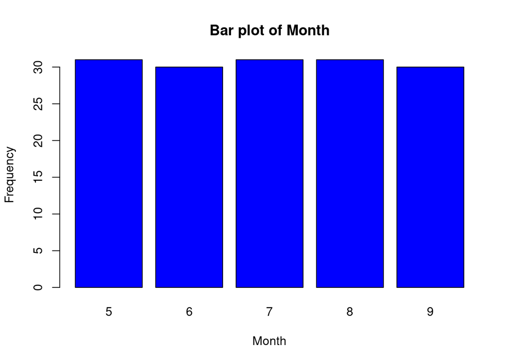

```r
barplot(table(aq$Month),
  main = "Bar plot of Month",
  xlab = "Month",
  ylab = "Frequency",
  col = "blue")
```

## b. Create a histogram of Temp variable and interpret

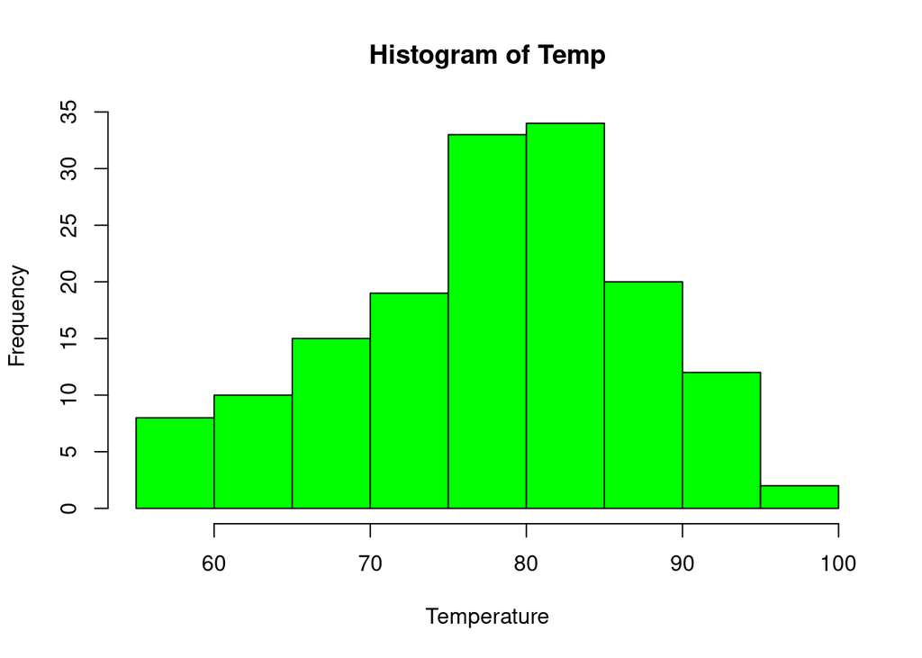

```r
hist(aq$Temp,
  main = "Histogram of Temp",
  xlab = "Temperature",
  ylab = "Frequency",
  col = "green"
)
```

## c. Create line plot of Temp and Day and interpet

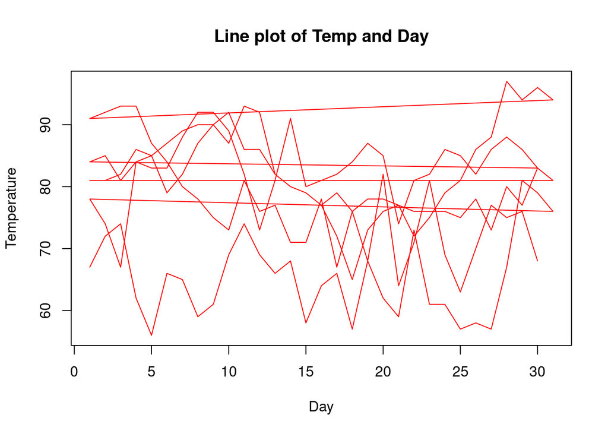

```r
plot(aq$Day, aq$Temp,
  type = "l",
  main = "Line plot of Temp and Day",
  xlab = "Day",
  ylab = "Temperature",
  col = "red"
)
```

## d. Create a scatter plot of Ozone and Solar and interpret

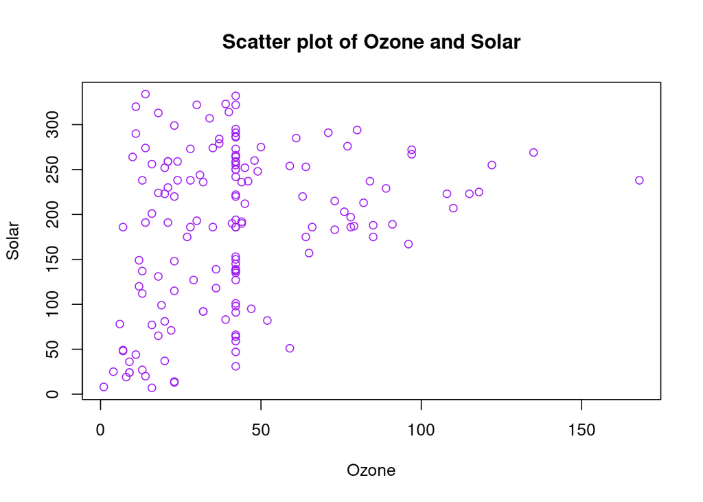

```r
plot(aq$Ozone, aq$Solar.R,
  main = "Scatter plot of Ozone and Solar",
  xlab = "Ozone",
  ylab = "Solar",
  col = "purple"
)
```

### Interpretation - The scatter plot shows the relationship between ozone and solar radiation.  
- There is a positive correlation between ozone and solar radiation, indicating that as ozone levels increase, solar radiation also increases. - The scatter plot also shows some outliers, indicating that there are some extreme values in the dataset.

# QN 9.Do the following with tidyverse package

### a. Define tibble having country, year, cases and population with 20 random values in each

```r
#library(tidyverse)
library(tibble)
set.seed(39)
country <- sample(c("USA", "India", "China", "Brazil", "UK"), 20, replace = TRUE)
year <- sample(2000:2020, 20, replace = TRUE)
cases <- sample(1000:10000, 20, replace = TRUE)
population <- sample(1000000:10000000, 20, replace = TRUE)
tibble_data <- tibble(country, year, cases, population)
tibble_data
```

```
## # A tibble: 20 × 4
##    country  year cases population
##    <chr>   <int> <int>      <int>
##  1 USA      2001  4896    6412862
##  2 China    2010  4495    5184409
##  3 India    2008  6008    9636320
##  4 UK       2009  9914    3341661
##  5 Brazil   2010  3828    1761401
##  6 UK       2011  6294    3481156
##  7 India    2015  8348    8757413
##  8 India    2003  5332    4269274
##  9 UK       2007  5880    8595526
## 10 USA      2018  7745    4137856
## 11 UK       2020  8859    7728717
## 12 China    2010  3939    4938436
## 13 China    2020  6154    8629126
## 14 China    2002  2027    4541162
## 15 China    2017  3856    5666481
## 16 India    2004  5534    4172009
## 17 India    2014  3662    4080855
## 18 China    2015  3202    9910839
## 19 USA      2004  8335    9943920
## 20 India    2014  3187    1890920
```

### b. Transform the cases as log of cases(LnCase) and population as log of population(LnPop)

```r
library(dplyr)
tibble_data <- tibble_data %>%
  filter(cases > 0, population > 0) %>%  # Remove non-positive values
  mutate(LnCase = log(cases),
         LnPop = log(population))
tibble_data
```

```
## # A tibble: 20 × 6
##    country  year cases population LnCase LnPop
##    <chr>   <int> <int>      <int>  <dbl> <dbl>
##  1 USA      2001  4896    6412862   8.50  15.7
##  2 China    2010  4495    5184409   8.41  15.5
##  3 India    2008  6008    9636320   8.70  16.1
##  4 UK       2009  9914    3341661   9.20  15.0
##  5 Brazil   2010  3828    1761401   8.25  14.4
##  6 UK       2011  6294    3481156   8.75  15.1
##  7 India    2015  8348    8757413   9.03  16.0
##  8 India    2003  5332    4269274   8.58  15.3
##  9 UK       2007  5880    8595526   8.68  16.0
## 10 USA      2018  7745    4137856   8.95  15.2
## 11 UK       2020  8859    7728717   9.09  15.9
## 12 China    2010  3939    4938436   8.28  15.4
## 13 China    2020  6154    8629126   8.72  16.0
## 14 China    2002  2027    4541162   7.61  15.3
## 15 China    2017  3856    5666481   8.26  15.6
## 16 India    2004  5534    4172009   8.62  15.2
## 17 India    2014  3662    4080855   8.21  15.2
## 18 China    2015  3202    9910839   8.07  16.1
## 19 USA      2004  8335    9943920   9.03  16.1
## 20 India    2014  3187    1890920   8.07  14.5
```